# Risk Factor Analysis

## Outcome Variable

**Outcome Variable:** stunted

## Predictor Variables

**Intervention Variable:** tr

**Adjustment Set:**

unadjusted

## Stratifying Variables

The analysis was stratified on these variable(s):

- predexfd6
- agecat
- studyid
- country

## Data Summary

| predexfd6 | agecat | studyid | country | tr | stunted | n_cell | n |
| --- | --- | --- | --- | --- | --- | --- | --- |
| 1 | 6 months | ki1000304b-SAS-CompFeed | INDIA | Control | 0 | 67 | 257 |
| 1 | 6 months | ki1000304b-SAS-CompFeed | INDIA | Control | 1 | 30 | 257 |
| 1 | 6 months | ki1000304b-SAS-CompFeed | INDIA | Other | 0 | 114 | 257 |
| 1 | 6 months | ki1000304b-SAS-CompFeed | INDIA | Other | 1 | 46 | 257 |
| 1 | Birth | ki1000304b-SAS-CompFeed | INDIA | Control | 0 | 12 | 36 |
| 1 | Birth | ki1000304b-SAS-CompFeed | INDIA | Control | 1 | 2 | 36 |
| 1 | Birth | ki1000304b-SAS-CompFeed | INDIA | Other | 0 | 20 | 36 |
| 1 | Birth | ki1000304b-SAS-CompFeed | INDIA | Other | 1 | 2 | 36 |
| 0 | Birth | ki1000304b-SAS-CompFeed | INDIA | Control | 0 | 1 | 1 |
| 0 | 6 months | ki1000304b-SAS-CompFeed | INDIA | Control | 0 | 7 | 14 |
| 0 | 6 months | ki1000304b-SAS-CompFeed | INDIA | Control | 1 | 3 | 14 |
| 0 | 6 months | ki1000304b-SAS-CompFeed | INDIA | Other | 0 | 4 | 14 |
| 0 | 6 months | ki1000304b-SAS-CompFeed | INDIA | Other | 1 | 0 | 14 |
| 0 | 6 months | ki1000304b-SAS-FoodSuppl | INDIA | Control | 0 | 17 | 160 |
| 0 | 6 months | ki1000304b-SAS-FoodSuppl | INDIA | Control | 1 | 24 | 160 |
| 0 | 6 months | ki1000304b-SAS-FoodSuppl | INDIA | Other | 0 | 67 | 160 |
| 0 | 6 months | ki1000304b-SAS-FoodSuppl | INDIA | Other | 1 | 52 | 160 |
| 0 | 6 months | ki1017093b-PROVIDE | BANGLADESH | Control | 0 | 4 | 18 |
| 0 | 6 months | ki1017093b-PROVIDE | BANGLADESH | Control | 1 | 0 | 18 |
| 0 | 6 months | ki1017093b-PROVIDE | BANGLADESH | Other | 0 | 10 | 18 |
| 0 | 6 months | ki1017093b-PROVIDE | BANGLADESH | Other | 1 | 4 | 18 |
| 1 | 6 months | ki1017093b-PROVIDE | BANGLADESH | Control | 0 | 4 | 28 |
| 1 | 6 months | ki1017093b-PROVIDE | BANGLADESH | Control | 1 | 2 | 28 |
| 1 | 6 months | ki1017093b-PROVIDE | BANGLADESH | Other | 0 | 18 | 28 |
| 1 | 6 months | ki1017093b-PROVIDE | BANGLADESH | Other | 1 | 4 | 28 |
| 0 | 24 months | ki1017093b-PROVIDE | BANGLADESH | Other | 0 | 1 | 1 |
| 1 | 24 months | ki1017093b-PROVIDE | BANGLADESH | Other | 0 | 1 | 1 |
| 1 | 6 months | ki1148112-iLiNS-DOSE | MALAWI | Control | 0 | 113 | 1014 |
| 1 | 6 months | ki1148112-iLiNS-DOSE | MALAWI | Control | 1 | 52 | 1014 |
| 1 | 6 months | ki1148112-iLiNS-DOSE | MALAWI | LNS | 0 | 614 | 1014 |

[output cut: 119 more lines]

The following strata were considered:

- predexfd6: 0, agecat: 24 months, studyid: ki1017093b-PROVIDE, country: BANGLADESH
- predexfd6: 0, agecat: 24 months, studyid: ki1148112-iLiNS-DOSE, country: MALAWI
- predexfd6: 0, agecat: 24 months, studyid: ki1148112-LCNI-5, country: MALAWI
- predexfd6: 0, agecat: 24 months, studyid: kiGH5241-JiVitA-3, country: BANGLADESH
- predexfd6: 0, agecat: 24 months, studyid: kiGH5241-JiVitA-4, country: BANGLADESH
- predexfd6: 0, agecat: 6 months, studyid: iLiNS_DYADM_LNS, country: MALAWI
- predexfd6: 0, agecat: 6 months, studyid: ki1000304b-SAS-CompFeed, country: INDIA
- predexfd6: 0, agecat: 6 months, studyid: ki1000304b-SAS-FoodSuppl, country: INDIA
- predexfd6: 0, agecat: 6 months, studyid: ki1017093b-PROVIDE, country: BANGLADESH
- predexfd6: 0, agecat: 6 months, studyid: ki1148112-iLiNS-DOSE, country: MALAWI
- predexfd6: 0, agecat: 6 months, studyid: ki1148112-iLiNS-DYAD-M, country: MALAWI
- predexfd6: 0, agecat: 6 months, studyid: ki1148112-LCNI-5, country: MALAWI
- predexfd6: 0, agecat: 6 months, studyid: kiGH5241-JiVitA-3, country: BANGLADESH
- predexfd6: 0, agecat: 6 months, studyid: kiGH5241-JiVitA-4, country: BANGLADESH
- predexfd6: 0, agecat: Birth, studyid: ki1000304b-SAS-CompFeed, country: INDIA
- predexfd6: 0, agecat: Birth, studyid: kiGH5241-JiVitA-3, country: BANGLADESH
- predexfd6: 0, agecat: Birth, studyid: kiGH5241-JiVitA-4, country: BANGLADESH
- predexfd6: 1, agecat: 24 months, studyid: iLiNS_DYADM_LNS, country: MALAWI
- predexfd6: 1, agecat: 24 months, studyid: ki1017093b-PROVIDE, country: BANGLADESH
- predexfd6: 1, agecat: 24 months, studyid: ki1148112-iLiNS-DOSE, country: MALAWI
- predexfd6: 1, agecat: 24 months, studyid: ki1148112-iLiNS-DYAD-M, country: MALAWI
- predexfd6: 1, agecat: 24 months, studyid: ki1148112-LCNI-5, country: MALAWI
- predexfd6: 1, agecat: 24 months, studyid: kiGH5241-JiVitA-3, country: BANGLADESH
- predexfd6: 1, agecat: 24 months, studyid: kiGH5241-JiVitA-4, country: BANGLADESH
- predexfd6: 1, agecat: 6 months, studyid: iLiNS_DYADM_LNS, country: MALAWI
- predexfd6: 1, agecat: 6 months, studyid: ki1000304b-SAS-CompFeed, country: INDIA
- predexfd6: 1, agecat: 6 months, studyid: ki1017093b-PROVIDE, country: BANGLADESH
- predexfd6: 1, agecat: 6 months, studyid: ki1148112-iLiNS-DOSE, country: MALAWI
- predexfd6: 1, agecat: 6 months, studyid: ki1148112-iLiNS-DYAD-M, country: MALAWI
- predexfd6: 1, agecat: 6 months, studyid: ki1148112-LCNI-5, country: MALAWI
- predexfd6: 1, agecat: 6 months, studyid: kiGH5241-JiVitA-3, country: BANGLADESH
- predexfd6: 1, agecat: 6 months, studyid: kiGH5241-JiVitA-4, country: BANGLADESH
- predexfd6: 1, agecat: Birth, studyid: ki1000304b-SAS-CompFeed, country: INDIA
- predexfd6: 1, agecat: Birth, studyid: kiGH5241-JiVitA-3, country: BANGLADESH
- predexfd6: 1, agecat: Birth, studyid: kiGH5241-JiVitA-4, country: BANGLADESH

### Dropped Strata

Some strata were dropped due to rare outcomes:

- predexfd6: 1, agecat: Birth, studyid: ki1000304b-SAS-CompFeed, country: INDIA
- predexfd6: 0, agecat: Birth, studyid: ki1000304b-SAS-CompFeed, country: INDIA
- predexfd6: 0, agecat: 6 months, studyid: ki1000304b-SAS-CompFeed, country: INDIA
- predexfd6: 0, agecat: 6 months, studyid: ki1017093b-PROVIDE, country: BANGLADESH
- predexfd6: 1, agecat: 6 months, studyid: ki1017093b-PROVIDE, country: BANGLADESH
- predexfd6: 0, agecat: 24 months, studyid: ki1017093b-PROVIDE, country: BANGLADESH
- predexfd6: 1, agecat: 24 months, studyid: ki1017093b-PROVIDE, country: BANGLADESH
- predexfd6: 0, agecat: 24 months, studyid: ki1148112-iLiNS-DOSE, country: MALAWI
- predexfd6: 1, agecat: 24 months, studyid: ki1148112-iLiNS-DYAD-M, country: MALAWI
- predexfd6: 0, agecat: 6 months, studyid: ki1148112-iLiNS-DYAD-M, country: MALAWI
- predexfd6: 1, agecat: 6 months, studyid: ki1148112-LCNI-5, country: MALAWI
- predexfd6: 0, agecat: 24 months, studyid: ki1148112-LCNI-5, country: MALAWI
- predexfd6: 1, agecat: 24 months, studyid: ki1148112-LCNI-5, country: MALAWI
- predexfd6: 0, agecat: 24 months, studyid: kiGH5241-JiVitA-3, country: BANGLADESH
- predexfd6: 1, agecat: 24 months, studyid: iLiNS_DYADM_LNS, country: MALAWI
- predexfd6: 0, agecat: 6 months, studyid: iLiNS_DYADM_LNS, country: MALAWI

## Methods Detail

We’re interested in the causal parameters $E[Y_a]$ for all values of $a \in \mathcal{A}$. These parameters represent the mean outcome if, possibly contrary to fact, we intervened to set all units to have $A=a$. Under the randomization and positivity assumptions, these are identified by the statistical parameters $\psi_a=E_W[E_{Y|A,W}(Y|A=a,W)]$. In addition, we’re interested in the mean of $Y$, $E[Y]$ under no intervention (the observed mean). We will estimate these parameters by using SuperLearner to fit the relevant likelihood factors – $E_{Y|A,W}(Y|A=a,W)$ and $p(A=a|W)$, and then updating our likelihood fit using a joint TMLE.

For unadjusted analyses ($W=\{\}$), initial likelihoods were estimated using Lrnr_glm to estimate the simple $E(Y|A)$ and Lrnr_mean to estimate $p(A)$. For adjusted analyses, a small library containing Lrnr_glmnet, Lrnr_xgboost, and Lrnr_mean was used.

Having estimated these parameters, we will then use the delta method to estimate relative risks and attributable risks relative to a prespecified baseline level of $A$.

# Results Detail

## Results Plots

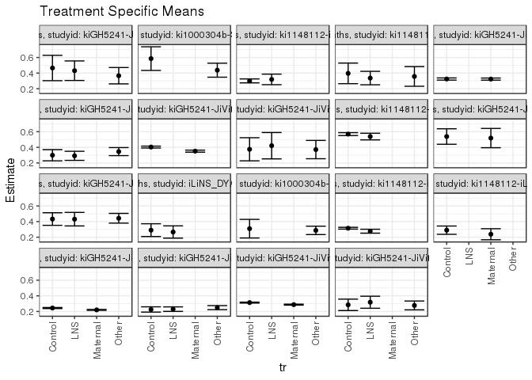

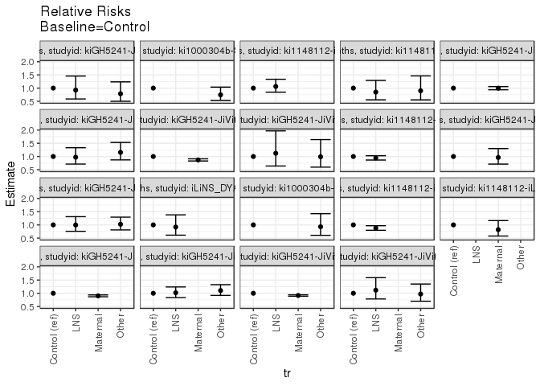

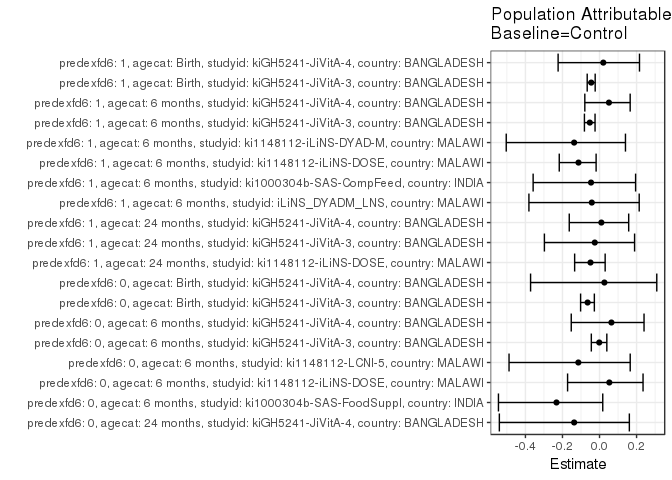

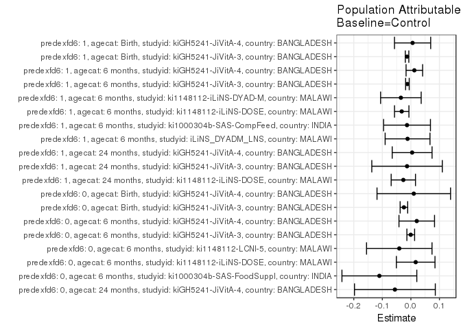

## Results Table

### Parameter: TSM

| predexfd6 | agecat | studyid | country | intervention_level | baseline_level | estimate | ci_lower | ci_upper |
| --- | --- | --- | --- | --- | --- | --- | --- | --- |
| 0 | Birth | kiGH5241-JiVitA-3 | BANGLADESH | Control | NA | 0.4034840 | 0.3914734 | 0.4154946 |
| 0 | Birth | kiGH5241-JiVitA-3 | BANGLADESH | Maternal | NA | 0.3512352 | 0.3382223 | 0.3642482 |
| 0 | Birth | kiGH5241-JiVitA-4 | BANGLADESH | Control | NA | 0.3750000 | 0.2270859 | 0.5229141 |
| 0 | Birth | kiGH5241-JiVitA-4 | BANGLADESH | LNS | NA | 0.4210526 | 0.2524572 | 0.5896480 |
| 0 | Birth | kiGH5241-JiVitA-4 | BANGLADESH | Other | NA | 0.3714286 | 0.2543774 | 0.4884797 |
| 0 | 6 months | ki1000304b-SAS-FoodSuppl | INDIA | Control | NA | 0.5853659 | 0.4340920 | 0.7366397 |
| 0 | 6 months | ki1000304b-SAS-FoodSuppl | INDIA | Other | NA | 0.4369748 | 0.3475767 | 0.5263729 |
| 0 | 6 months | ki1148112-iLiNS-DOSE | MALAWI | Control | NA | 0.3000000 | 0.2749735 | 0.3250265 |
| 0 | 6 months | ki1148112-iLiNS-DOSE | MALAWI | LNS | NA | 0.3191489 | 0.2515550 | 0.3867428 |
| 0 | 6 months | ki1148112-LCNI-5 | MALAWI | Control | NA | 0.3962264 | 0.2642531 | 0.5281997 |
| 0 | 6 months | ki1148112-LCNI-5 | MALAWI | LNS | NA | 0.3362069 | 0.2500468 | 0.4223670 |
| 0 | 6 months | ki1148112-LCNI-5 | MALAWI | Other | NA | 0.3571429 | 0.2313663 | 0.4829194 |
| 0 | 6 months | kiGH5241-JiVitA-3 | BANGLADESH | Control | NA | 0.3240950 | 0.3102774 | 0.3379126 |
| 0 | 6 months | kiGH5241-JiVitA-3 | BANGLADESH | Maternal | NA | 0.3230676 | 0.3095466 | 0.3365887 |
| 0 | 6 months | kiGH5241-JiVitA-4 | BANGLADESH | Control | NA | 0.2990654 | 0.2273176 | 0.3708133 |
| 0 | 6 months | kiGH5241-JiVitA-4 | BANGLADESH | LNS | NA | 0.2914980 | 0.2333439 | 0.3496520 |
| 0 | 6 months | kiGH5241-JiVitA-4 | BANGLADESH | Other | NA | 0.3455378 | 0.2941389 | 0.3969367 |
| 0 | 24 months | kiGH5241-JiVitA-4 | BANGLADESH | Control | NA | 0.4651163 | 0.3028706 | 0.6273620 |
| 0 | 24 months | kiGH5241-JiVitA-4 | BANGLADESH | LNS | NA | 0.4307692 | 0.3056746 | 0.5558638 |
| 0 | 24 months | kiGH5241-JiVitA-4 | BANGLADESH | Other | NA | 0.3666667 | 0.2620154 | 0.4713180 |
| 1 | Birth | kiGH5241-JiVitA-3 | BANGLADESH | Control | NA | 0.3135789 | 0.3076498 | 0.3195080 |
| 1 | Birth | kiGH5241-JiVitA-3 | BANGLADESH | Maternal | NA | 0.2873756 | 0.2813163 | 0.2934349 |
| 1 | Birth | kiGH5241-JiVitA-4 | BANGLADESH | Control | NA | 0.2848485 | 0.2116311 | 0.3580658 |
| 1 | Birth | kiGH5241-JiVitA-4 | BANGLADESH | LNS | NA | 0.3181818 | 0.2410489 | 0.3953147 |
| 1 | Birth | kiGH5241-JiVitA-4 | BANGLADESH | Other | NA | 0.2769784 | 0.2204503 | 0.3335066 |
| 1 | 6 months | iLiNS_DYADM_LNS | MALAWI | Control | NA | 0.2903226 | 0.2084461 | 0.3721991 |
| 1 | 6 months | iLiNS_DYADM_LNS | MALAWI | LNS | NA | 0.2666667 | 0.1881967 | 0.3451366 |
| 1 | 6 months | ki1000304b-SAS-CompFeed | INDIA | Control | NA | 0.3092784 | 0.1900328 | 0.4285239 |
| 1 | 6 months | ki1000304b-SAS-CompFeed | INDIA | Other | NA | 0.2875000 | 0.2339413 | 0.3410587 |
| 1 | 6 months | ki1148112-iLiNS-DOSE | MALAWI | Control | NA | 0.3151515 | 0.3036111 | 0.3266920 |
| 1 | 6 months | ki1148112-iLiNS-DOSE | MALAWI | LNS | NA | 0.2767962 | 0.2515853 | 0.3020071 |
| 1 | 6 months | ki1148112-iLiNS-DYAD-M | MALAWI | Control | NA | 0.2903226 | 0.2373447 | 0.3433004 |
| 1 | 6 months | ki1148112-iLiNS-DYAD-M | MALAWI | Maternal | NA | 0.2380952 | 0.1672291 | 0.3089614 |
| 1 | 6 months | kiGH5241-JiVitA-3 | BANGLADESH | Control | NA | 0.2440872 | 0.2374831 | 0.2506912 |
| 1 | 6 months | kiGH5241-JiVitA-3 | BANGLADESH | Maternal | NA | 0.2202611 | 0.2140420 | 0.2264801 |
| 1 | 6 months | kiGH5241-JiVitA-4 | BANGLADESH | Control | NA | 0.2255814 | 0.1917254 | 0.2594373 |
| 1 | 6 months | kiGH5241-JiVitA-4 | BANGLADESH | LNS | NA | 0.2299349 | 0.2009727 | 0.2588972 |
| 1 | 6 months | kiGH5241-JiVitA-4 | BANGLADESH | Other | NA | 0.2490298 | 0.2230171 | 0.2750424 |
| 1 | 24 months | ki1148112-iLiNS-DOSE | MALAWI | Control | NA | 0.5694444 | 0.5507925 | 0.5880964 |
| 1 | 24 months | ki1148112-iLiNS-DOSE | MALAWI | LNS | NA | 0.5378378 | 0.4952641 | 0.5804115 |
| 1 | 24 months | kiGH5241-JiVitA-3 | BANGLADESH | Control | NA | 0.5384615 | 0.4392149 | 0.6377082 |
| 1 | 24 months | kiGH5241-JiVitA-3 | BANGLADESH | Maternal | NA | 0.5185185 | 0.3950500 | 0.6419870 |
| 1 | 24 months | kiGH5241-JiVitA-4 | BANGLADESH | Control | NA | 0.4325843 | 0.3519158 | 0.5132527 |
| 1 | 24 months | kiGH5241-JiVitA-4 | BANGLADESH | LNS | NA | 0.4310345 | 0.3443701 | 0.5176988 |
| 1 | 24 months | kiGH5241-JiVitA-4 | BANGLADESH | Other | NA | 0.4426752 | 0.3802475 | 0.5051028 |

### Parameter: E(Y)

| predexfd6 | agecat | studyid | country | intervention_level | baseline_level | estimate | ci_lower | ci_upper |
| --- | --- | --- | --- | --- | --- | --- | --- | --- |
| 0 | Birth | kiGH5241-JiVitA-3 | BANGLADESH | NA | NA | 0.3790768 | 0.3612523 | 0.3969013 |
| 0 | Birth | kiGH5241-JiVitA-4 | BANGLADESH | NA | NA | 0.3851351 | 0.3041471 | 0.4661232 |
| 0 | 6 months | ki1000304b-SAS-FoodSuppl | INDIA | NA | NA | 0.4750000 | 0.3973796 | 0.5526204 |
| 0 | 6 months | ki1148112-iLiNS-DOSE | MALAWI | NA | NA | 0.3167702 | 0.2446854 | 0.3888550 |
| 0 | 6 months | ki1148112-LCNI-5 | MALAWI | NA | NA | 0.3555556 | 0.2928696 | 0.4182416 |
| 0 | 6 months | kiGH5241-JiVitA-3 | BANGLADESH | NA | NA | 0.3235981 | 0.3042651 | 0.3429312 |
| 0 | 6 months | kiGH5241-JiVitA-4 | BANGLADESH | NA | NA | 0.3195991 | 0.2851973 | 0.3540009 |
| 0 | 24 months | kiGH5241-JiVitA-4 | BANGLADESH | NA | NA | 0.4090909 | 0.3365982 | 0.4815837 |
| 1 | Birth | kiGH5241-JiVitA-3 | BANGLADESH | NA | NA | 0.3001457 | 0.2915966 | 0.3086949 |
| 1 | Birth | kiGH5241-JiVitA-4 | BANGLADESH | NA | NA | 0.2907916 | 0.2518865 | 0.3296967 |
| 1 | 6 months | iLiNS_DYADM_LNS | MALAWI | NA | NA | 0.2786885 | 0.1652414 | 0.3921356 |
| 1 | 6 months | ki1000304b-SAS-CompFeed | INDIA | NA | NA | 0.2957198 | 0.2395510 | 0.3518887 |
| 1 | 6 months | ki1148112-iLiNS-DOSE | MALAWI | NA | NA | 0.2830375 | 0.2552970 | 0.3107779 |
| 1 | 6 months | ki1148112-iLiNS-DYAD-M | MALAWI | NA | NA | 0.2553191 | 0.1666988 | 0.3439395 |
| 1 | 6 months | kiGH5241-JiVitA-3 | BANGLADESH | NA | NA | 0.2319279 | 0.2228159 | 0.2410400 |
| 1 | 6 months | kiGH5241-JiVitA-4 | BANGLADESH | NA | NA | 0.2376803 | 0.2206903 | 0.2546703 |
| 1 | 24 months | ki1148112-iLiNS-DOSE | MALAWI | NA | NA | 0.5429864 | 0.4964934 | 0.5894795 |
| 1 | 24 months | kiGH5241-JiVitA-3 | BANGLADESH | NA | NA | 0.5250000 | 0.3666127 | 0.6833873 |
| 1 | 24 months | kiGH5241-JiVitA-4 | BANGLADESH | NA | NA | 0.4369369 | 0.3939807 | 0.4798931 |

### Parameter: RR

| predexfd6 | agecat | studyid | country | intervention_level | baseline_level | estimate | ci_lower | ci_upper |
| --- | --- | --- | --- | --- | --- | --- | --- | --- |
| 0 | Birth | kiGH5241-JiVitA-3 | BANGLADESH | Control | Control | 1.0000000 | 1.0000000 | 1.0000000 |
| 0 | Birth | kiGH5241-JiVitA-3 | BANGLADESH | Maternal | Control | 0.8705060 | 0.8300995 | 0.9128794 |
| 0 | Birth | kiGH5241-JiVitA-4 | BANGLADESH | Control | Control | 1.0000000 | 1.0000000 | 1.0000000 |
| 0 | Birth | kiGH5241-JiVitA-4 | BANGLADESH | LNS | Control | 1.1228070 | 0.6400633 | 1.9696420 |
| 0 | Birth | kiGH5241-JiVitA-4 | BANGLADESH | Other | Control | 0.9904762 | 0.5978764 | 1.6408795 |
| 0 | 6 months | ki1000304b-SAS-FoodSuppl | INDIA | Control | Control | 1.0000000 | 1.0000000 | 1.0000000 |
| 0 | 6 months | ki1000304b-SAS-FoodSuppl | INDIA | Other | Control | 0.7464986 | 0.5368882 | 1.0379445 |
| 0 | 6 months | ki1148112-iLiNS-DOSE | MALAWI | Control | Control | 1.0000000 | 1.0000000 | 1.0000000 |
| 0 | 6 months | ki1148112-iLiNS-DOSE | MALAWI | LNS | Control | 1.0638298 | 0.8472531 | 1.3357682 |
| 0 | 6 months | ki1148112-LCNI-5 | MALAWI | Control | Control | 1.0000000 | 1.0000000 | 1.0000000 |
| 0 | 6 months | ki1148112-LCNI-5 | MALAWI | LNS | Control | 0.8485222 | 0.5573767 | 1.2917473 |
| 0 | 6 months | ki1148112-LCNI-5 | MALAWI | Other | Control | 0.9013605 | 0.5551134 | 1.4635763 |
| 0 | 6 months | kiGH5241-JiVitA-3 | BANGLADESH | Control | Control | 1.0000000 | 1.0000000 | 1.0000000 |
| 0 | 6 months | kiGH5241-JiVitA-3 | BANGLADESH | Maternal | Control | 0.9968300 | 0.9390232 | 1.0581953 |
| 0 | 6 months | kiGH5241-JiVitA-4 | BANGLADESH | Control | Control | 1.0000000 | 1.0000000 | 1.0000000 |
| 0 | 6 months | kiGH5241-JiVitA-4 | BANGLADESH | LNS | Control | 0.9746964 | 0.7132826 | 1.3319167 |
| 0 | 6 months | kiGH5241-JiVitA-4 | BANGLADESH | Other | Control | 1.1553919 | 0.8712120 | 1.5322682 |
| 0 | 24 months | kiGH5241-JiVitA-4 | BANGLADESH | Control | Control | 1.0000000 | 1.0000000 | 1.0000000 |
| 0 | 24 months | kiGH5241-JiVitA-4 | BANGLADESH | LNS | Control | 0.9261538 | 0.5883840 | 1.4578250 |
| 0 | 24 months | kiGH5241-JiVitA-4 | BANGLADESH | Other | Control | 0.7883333 | 0.5023638 | 1.2370905 |
| 1 | Birth | kiGH5241-JiVitA-3 | BANGLADESH | Control | Control | 1.0000000 | 1.0000000 | 1.0000000 |
| 1 | Birth | kiGH5241-JiVitA-3 | BANGLADESH | Maternal | Control | 0.9164380 | 0.8908429 | 0.9427685 |
| 1 | Birth | kiGH5241-JiVitA-4 | BANGLADESH | Control | Control | 1.0000000 | 1.0000000 | 1.0000000 |
| 1 | Birth | kiGH5241-JiVitA-4 | BANGLADESH | LNS | Control | 1.1170213 | 0.7845663 | 1.5903518 |
| 1 | Birth | kiGH5241-JiVitA-4 | BANGLADESH | Other | Control | 0.9723710 | 0.7002624 | 1.3502160 |
| 1 | 6 months | iLiNS_DYADM_LNS | MALAWI | Control | Control | 1.0000000 | 1.0000000 | 1.0000000 |
| 1 | 6 months | iLiNS_DYADM_LNS | MALAWI | LNS | Control | 0.9185185 | 0.6110493 | 1.3807007 |
| 1 | 6 months | ki1000304b-SAS-CompFeed | INDIA | Control | Control | 1.0000000 | 1.0000000 | 1.0000000 |
| 1 | 6 months | ki1000304b-SAS-CompFeed | INDIA | Other | Control | 0.9295833 | 0.6059180 | 1.4261421 |
| 1 | 6 months | ki1148112-iLiNS-DOSE | MALAWI | Control | Control | 1.0000000 | 1.0000000 | 1.0000000 |
| 1 | 6 months | ki1148112-iLiNS-DOSE | MALAWI | LNS | Control | 0.8782957 | 0.7961731 | 0.9688891 |
| 1 | 6 months | ki1148112-iLiNS-DYAD-M | MALAWI | Control | Control | 1.0000000 | 1.0000000 | 1.0000000 |
| 1 | 6 months | ki1148112-iLiNS-DYAD-M | MALAWI | Maternal | Control | 0.8201058 | 0.5784258 | 1.1627654 |
| 1 | 6 months | kiGH5241-JiVitA-3 | BANGLADESH | Control | Control | 1.0000000 | 1.0000000 | 1.0000000 |
| 1 | 6 months | kiGH5241-JiVitA-3 | BANGLADESH | Maternal | Control | 0.9023868 | 0.8677702 | 0.9383843 |
| 1 | 6 months | kiGH5241-JiVitA-4 | BANGLADESH | Control | Control | 1.0000000 | 1.0000000 | 1.0000000 |
| 1 | 6 months | kiGH5241-JiVitA-4 | BANGLADESH | LNS | Control | 1.0192991 | 0.8378447 | 1.2400517 |
| 1 | 6 months | kiGH5241-JiVitA-4 | BANGLADESH | Other | Control | 1.1039463 | 0.9194784 | 1.3254226 |
| 1 | 24 months | ki1148112-iLiNS-DOSE | MALAWI | Control | Control | 1.0000000 | 1.0000000 | 1.0000000 |
| 1 | 24 months | ki1148112-iLiNS-DOSE | MALAWI | LNS | Control | 0.9444957 | 0.8669531 | 1.0289740 |
| 1 | 24 months | kiGH5241-JiVitA-3 | BANGLADESH | Control | Control | 1.0000000 | 1.0000000 | 1.0000000 |
| 1 | 24 months | kiGH5241-JiVitA-3 | BANGLADESH | Maternal | Control | 0.9629630 | 0.7125833 | 1.3013183 |
| 1 | 24 months | kiGH5241-JiVitA-4 | BANGLADESH | Control | Control | 1.0000000 | 1.0000000 | 1.0000000 |
| 1 | 24 months | kiGH5241-JiVitA-4 | BANGLADESH | LNS | Control | 0.9964174 | 0.7574078 | 1.3108494 |
| 1 | 24 months | kiGH5241-JiVitA-4 | BANGLADESH | Other | Control | 1.0233270 | 0.8100031 | 1.2928322 |

### Parameter: PAR

| predexfd6 | agecat | studyid | country | intervention_level | baseline_level | estimate | ci_lower | ci_upper |
| --- | --- | --- | --- | --- | --- | --- | --- | --- |
| 0 | Birth | kiGH5241-JiVitA-3 | BANGLADESH | Control | NA | -0.0244072 | -0.0376080 | -0.0112064 |
| 0 | Birth | kiGH5241-JiVitA-4 | BANGLADESH | Control | NA | 0.0101351 | -0.1186353 | 0.1389056 |
| 0 | 6 months | ki1000304b-SAS-FoodSuppl | INDIA | Control | NA | -0.1103659 | -0.2414413 | 0.0207096 |
| 0 | 6 months | ki1148112-iLiNS-DOSE | MALAWI | Control | NA | 0.0167702 | -0.0508308 | 0.0843712 |
| 0 | 6 months | ki1148112-LCNI-5 | MALAWI | Control | NA | -0.0406709 | -0.1553058 | 0.0739641 |
| 0 | 6 months | kiGH5241-JiVitA-3 | BANGLADESH | Control | NA | -0.0004969 | -0.0140175 | 0.0130238 |
| 0 | 6 months | kiGH5241-JiVitA-4 | BANGLADESH | Control | NA | 0.0205337 | -0.0417193 | 0.0827866 |
| 0 | 24 months | kiGH5241-JiVitA-4 | BANGLADESH | Control | NA | -0.0560254 | -0.1975475 | 0.0854968 |
| 1 | Birth | kiGH5241-JiVitA-3 | BANGLADESH | Control | NA | -0.0134332 | -0.0196095 | -0.0072569 |
| 1 | Birth | kiGH5241-JiVitA-4 | BANGLADESH | Control | NA | 0.0059431 | -0.0574285 | 0.0693148 |
| 1 | 6 months | iLiNS_DYADM_LNS | MALAWI | Control | NA | -0.0116341 | -0.0901610 | 0.0668929 |
| 1 | 6 months | ki1000304b-SAS-CompFeed | INDIA | Control | NA | -0.0135585 | -0.0956081 | 0.0684910 |
| 1 | 6 months | ki1148112-iLiNS-DOSE | MALAWI | Control | NA | -0.0321140 | -0.0573400 | -0.0068881 |
| 1 | 6 months | ki1148112-iLiNS-DYAD-M | MALAWI | Control | NA | -0.0350034 | -0.1060450 | 0.0360382 |
| 1 | 6 months | kiGH5241-JiVitA-3 | BANGLADESH | Control | NA | -0.0121592 | -0.0184699 | -0.0058486 |
| 1 | 6 months | kiGH5241-JiVitA-4 | BANGLADESH | Control | NA | 0.0120989 | -0.0168901 | 0.0410879 |
| 1 | 24 months | ki1148112-iLiNS-DOSE | MALAWI | Control | NA | -0.0264580 | -0.0690457 | 0.0161296 |
| 1 | 24 months | kiGH5241-JiVitA-3 | BANGLADESH | Control | NA | -0.0134615 | -0.1368983 | 0.1099753 |
| 1 | 24 months | kiGH5241-JiVitA-4 | BANGLADESH | Control | NA | 0.0043527 | -0.0654478 | 0.0741531 |

### Parameter: PAF

| predexfd6 | agecat | studyid | country | intervention_level | baseline_level | estimate | ci_lower | ci_upper |
| --- | --- | --- | --- | --- | --- | --- | --- | --- |
| 0 | Birth | kiGH5241-JiVitA-3 | BANGLADESH | Control | NA | -0.0643860 | -0.1021573 | -0.0279091 |
| 0 | Birth | kiGH5241-JiVitA-4 | BANGLADESH | Control | NA | 0.0263158 | -0.3722101 | 0.3090993 |
| 0 | 6 months | ki1000304b-SAS-FoodSuppl | INDIA | Control | NA | -0.2323492 | -0.5456350 | 0.0174365 |
| 0 | 6 months | ki1148112-iLiNS-DOSE | MALAWI | Control | NA | 0.0529412 | -0.1724067 | 0.2349750 |
| 0 | 6 months | ki1148112-LCNI-5 | MALAWI | Control | NA | -0.1143868 | -0.4884734 | 0.1656835 |
| 0 | 6 months | kiGH5241-JiVitA-3 | BANGLADESH | Control | NA | -0.0015355 | -0.0442685 | 0.0394487 |
| 0 | 6 months | kiGH5241-JiVitA-4 | BANGLADESH | Control | NA | 0.0642483 | -0.1526199 | 0.2403122 |
| 0 | 24 months | kiGH5241-JiVitA-4 | BANGLADESH | Control | NA | -0.1369509 | -0.5407808 | 0.1610374 |
| 1 | Birth | kiGH5241-JiVitA-3 | BANGLADESH | Control | NA | -0.0447555 | -0.0664928 | -0.0234613 |
| 1 | Birth | kiGH5241-JiVitA-4 | BANGLADESH | Control | NA | 0.0204377 | -0.2235390 | 0.2157648 |
| 1 | 6 months | iLiNS_DYADM_LNS | MALAWI | Control | NA | -0.0417457 | -0.3811507 | 0.2142536 |
| 1 | 6 months | ki1000304b-SAS-CompFeed | INDIA | Control | NA | -0.0458492 | -0.3584062 | 0.1947913 |
| 1 | 6 months | ki1148112-iLiNS-DOSE | MALAWI | Control | NA | -0.1134621 | -0.2173751 | -0.0184190 |
| 1 | 6 months | ki1148112-iLiNS-DYAD-M | MALAWI | Control | NA | -0.1370968 | -0.5035771 | 0.1400580 |
| 1 | 6 months | kiGH5241-JiVitA-3 | BANGLADESH | Control | NA | -0.0524268 | -0.0814883 | -0.0241463 |
| 1 | 6 months | kiGH5241-JiVitA-4 | BANGLADESH | Control | NA | 0.0509041 | -0.0793797 | 0.1654623 |
| 1 | 24 months | ki1148112-iLiNS-DOSE | MALAWI | Control | NA | -0.0487269 | -0.1343109 | 0.0303999 |
| 1 | 24 months | kiGH5241-JiVitA-3 | BANGLADESH | Control | NA | -0.0256410 | -0.2975567 | 0.1892921 |
| 1 | 24 months | kiGH5241-JiVitA-4 | BANGLADESH | Control | NA | 0.0099618 | -0.1633613 | 0.1574624 |